# Pertemuan 7

Indra Maulana

# Diagnostik dan Peramalan

## Input Data

```r
data<- read.csv("C:/Users/LENOVO/Downloads/data.csv",sep = ";")
dim(data)
```

```
## [1] 241   2
```

```r
head(data)
```

```
##   bulan Inflasi
## 1     1      29
## 2     2      27
## 3     3      28
## 4     4      25
## 5     5      22
## 6     6      22
```

```r
str(data)
```

```
## 'data.frame':    241 obs. of  2 variables:
##  $ bulan  : int  1 2 3 4 5 6 7 8 9 10 ...
##  $ Inflasi: int  29 27 28 25 22 22 17 22 27 28 ...
```

```r
summary(data)
```

```
##      bulan        Inflasi
##  Min.   :  1   Min.   : 5.00
##  1st Qu.: 61   1st Qu.:15.00
##  Median :121   Median :21.00
##  Mean   :121   Mean   :24.58
##  3rd Qu.:181   3rd Qu.:30.00
##  Max.   :241   Max.   :78.00
```

```r
#Mengambil hanya kolom Close sebagai data baru
data.inflasi <- as.numeric(data$Inflasi)
head(data)
```

```
##   bulan Inflasi
## 1     1      29
## 2     2      27
## 3     3      28
## 4     4      25
## 5     5      22
## 6     6      22
```

```r
#Mengganti tipe data menjadi time series
data.ts<-ts(data.inflasi)
```

## Eksplorasi Data

### Plot untuk Seluruh Data

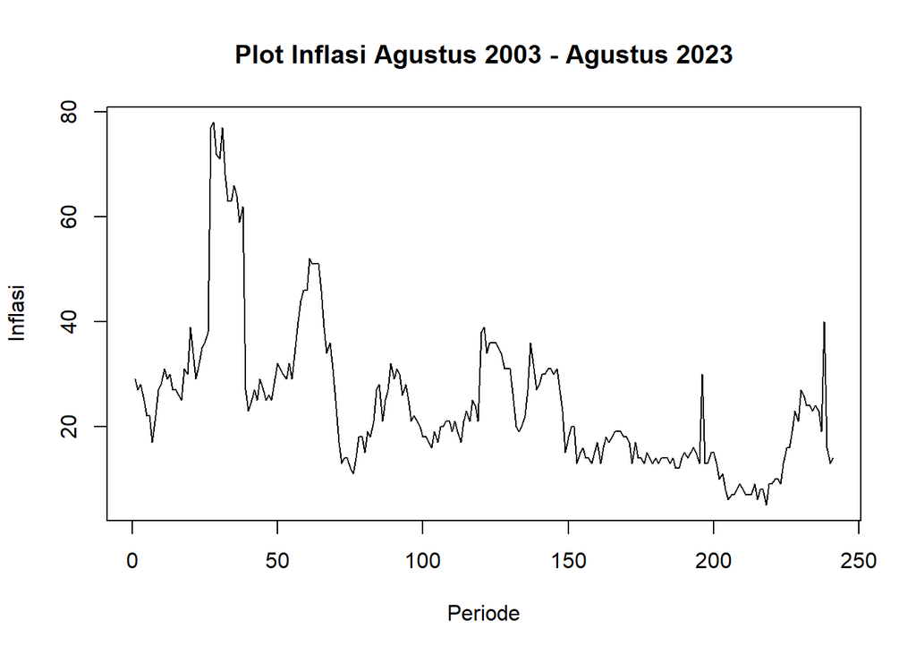

```r
plot.ts(data.ts, xlab="Periode", ylab="Inflasi", main="Plot Inflasi Agustus 2003 - Agustus 2023")
```

#### Plot Data Train

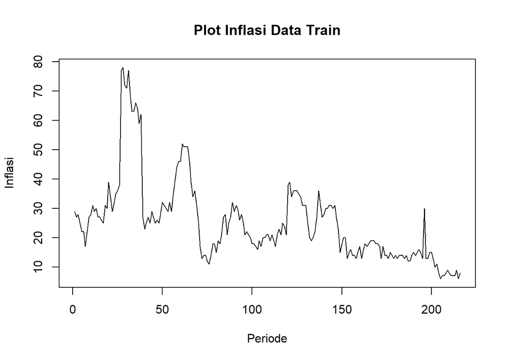

```r
datatrain<-data.inflasi[1:216]
train.ts<-ts(datatrain)
plot.ts(train.ts, lty=1, xlab="Periode", ylab="Inflasi", main="Plot Inflasi Data Train")
```

#### Plot Data Test

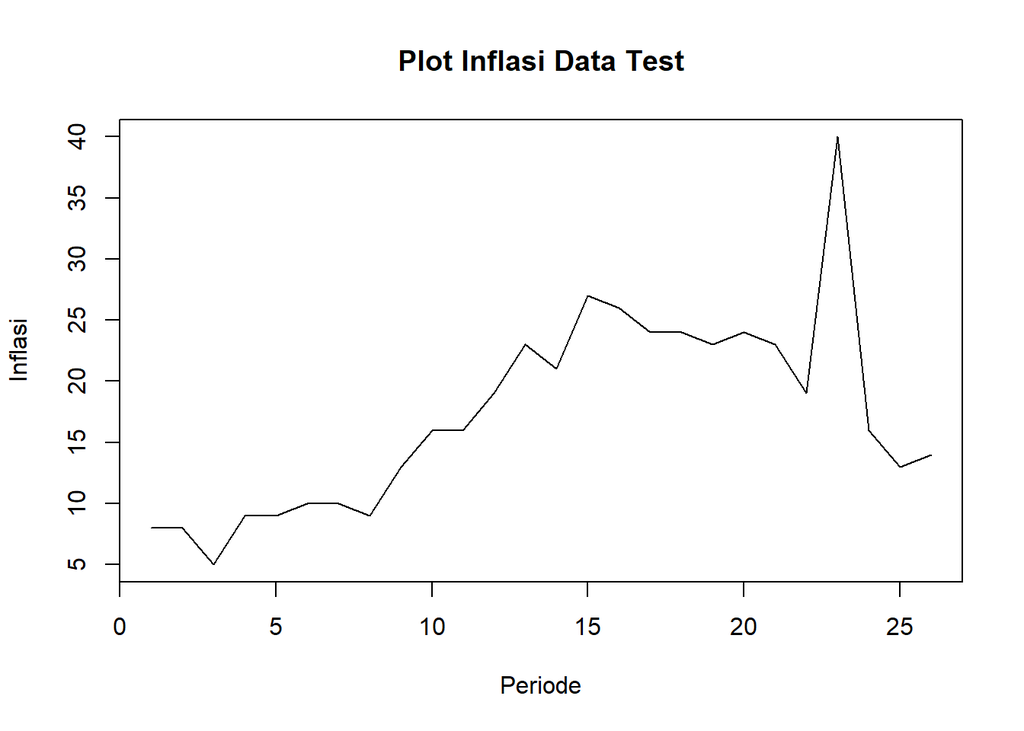

```r
datatest<-data.inflasi[216:241]
test.ts<-ts(datatest)
plot.ts(test.ts, lty=1, xlab="Periode", ylab="Inflasi", main="Plot Inflasi Data Test")
```

Plot data test mengindikasikan data tidak stasioner dalam rataan maupun ragam. Selanjutnya akan dilihat sifat stasioner data train melalui plot ACF, Uji ADF, dan plot Box-Cox

## Kestasioneran Data

### Plot ACF

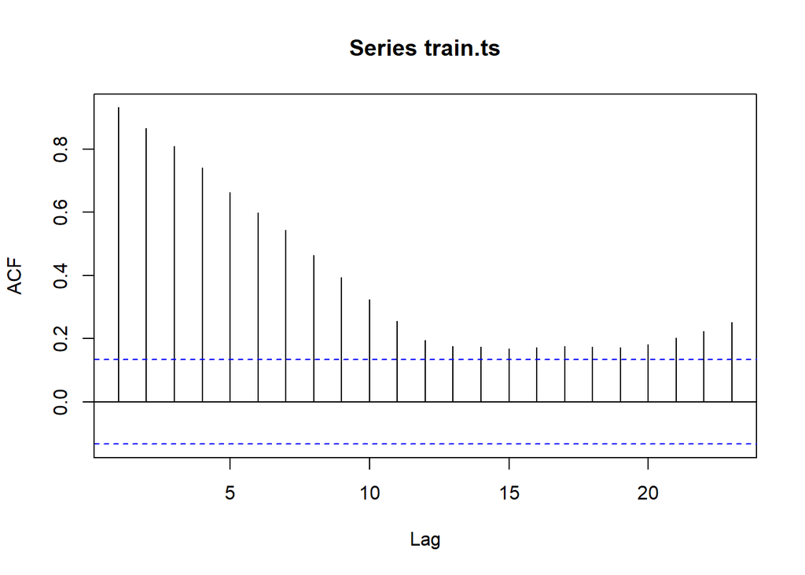

```r
acf(train.ts)
```

Plot ACF di atas menampilkan bahwa data menurun secara perlahan, artinya data diindikasi tidak stasioner dalam rataan.

### Uji ADF

H0: Data tidak stasioner dalam rataan H1: Data stasioner dalam rataan

```r
tseries::adf.test(train.ts)
```

```
##
##  Augmented Dickey-Fuller Test
##
## data:  train.ts
## Dickey-Fuller = -4.045, Lag order = 5, p-value = 0.01
## alternative hypothesis: stationary
```

### Plot Box-Cox

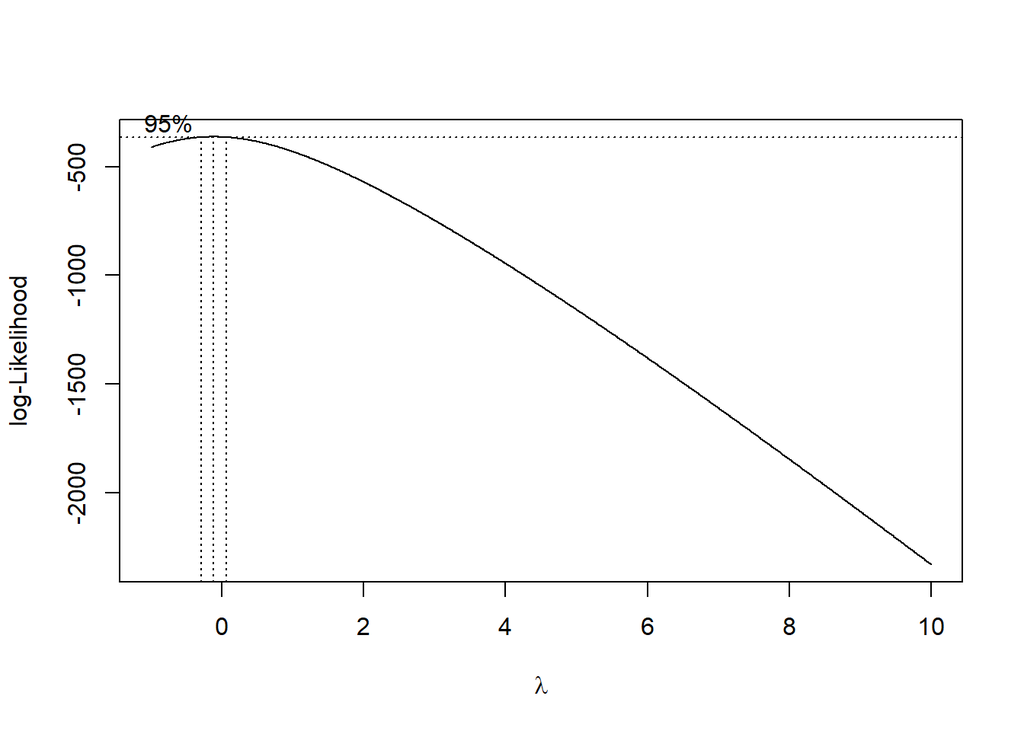

```r
index <- seq(1:216)
bc = boxcox(train.ts~index, lambda = seq(-1,10,by=0.01))
```

```r
#Nilai Rounded Lambda
lambda <- bc$x[which.max(bc$y)]
lambda
```

```
## [1] -0.12
```

```r
#SK
bc$x[bc$y > max(bc$y) - 1/2 * qchisq(.95,1)]
```

```
##  [1] -0.29 -0.28 -0.27 -0.26 -0.25 -0.24 -0.23 -0.22 -0.21 -0.20 -0.19 -0.18
## [13] -0.17 -0.16 -0.15 -0.14 -0.13 -0.12 -0.11 -0.10 -0.09 -0.08 -0.07 -0.06
## [25] -0.05 -0.04 -0.03 -0.02 -0.01  0.00  0.01  0.02  0.03  0.04  0.05
```

Plot Boxcox menunjukkan nilai lambda (λ) optimum sebesar -0.12. Pada selang kepercayaan 95% nilai memiliki batas bawah -0.29 dan batas atas 0.05. Selang tersebut tidak memuat nilai satu sehingga dapat dikatakan bahwa data yang digunakan tidak stasioner dalam ragam.

## Penanganan Ketakstasioneran Data

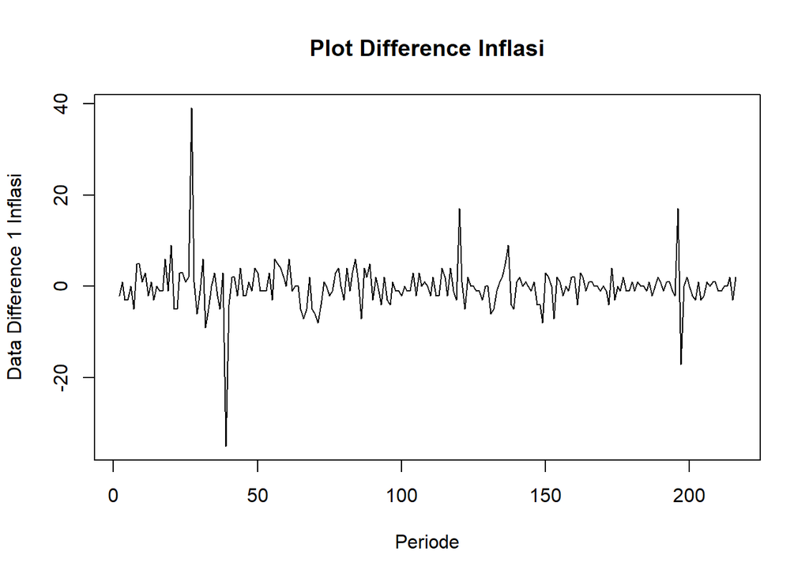

```r
train.diff<-diff(train.ts,differences = 1)
plot.ts(train.diff, lty=1, xlab="Periode", ylab="Data Difference 1 Inflasi", main="Plot Difference Inflasi")
```

Terlihat bahwa data cenderung telah stasioner dalam rataan. Selanjutnya akan dilakukan uji kestasioneran data menggunakan plot ACF dan Uji ADF.

### Plot ACF

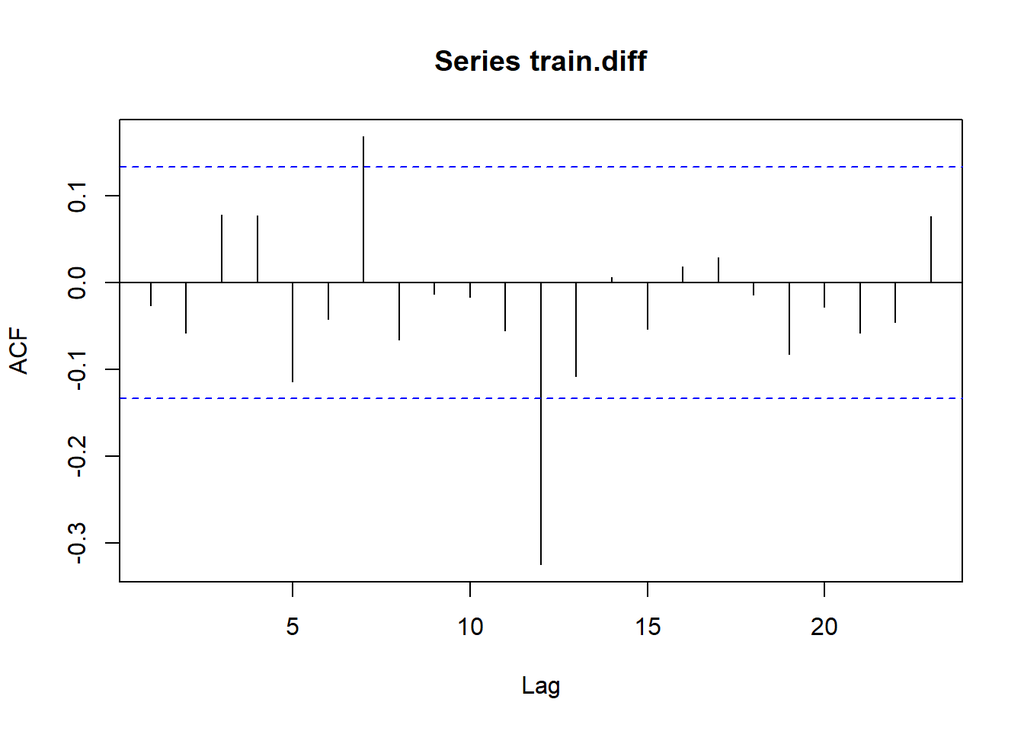

```r
acf(train.diff)
```

Terlihat bahwa data tidak lagi menurun secara perlahan. Hal ini menunjukkan data telah stasioner dalam rataan

### Uji ADF

H0: Data tidak stasioner dalam rataan H1: Data stasioner dalam rataan

```r
tseries::adf.test(train.diff)
```

```
##
##  Augmented Dickey-Fuller Test
##
## data:  train.diff
## Dickey-Fuller = -6.2722, Lag order = 5, p-value = 0.01
## alternative hypothesis: stationary
```

Berdasarkan hasil uji ADF, diperoleh p-value sebesar 0.01 < 0.05. Hal ini menunjukkan keputusan tolak H0, artinya data stasioner dalam rataan. Kestidakstasioneran data telah tertangani, selanjutnya akan dilakukan identifikasi model

## Identifikasi Model

### Plot ACF

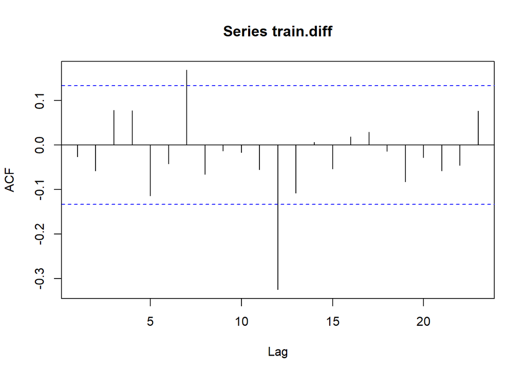

```r
acf(train.diff)
```

Identifikasi model menggunakan plot ACF tidak menampilkan data cuts off di lag mana pun kecuali lag 7 dan 12.

### Plot PACF

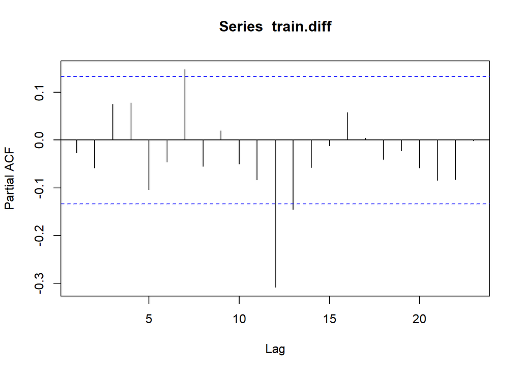

```r
pacf(train.diff)
```

Identifikasi model menggunakan plot PACF tidak menampilkan data cuts off di lag mana pun kecuali di lag 7,12,dan 13

### Plot EACF

```r
eacf(train.diff)
```

```
## AR/MA
##   0 1 2 3 4 5 6 7 8 9 10 11 12 13
## 0 o o o o o o x o o o o  x  o  o
## 1 x o o o o o o o o o o  x  o  o
## 2 x x o o o o o o o o o  x  x  o
## 3 x x x o o o o o o o o  x  x  o
## 4 x x x x o o o o o o o  x  o  o
## 5 x x x o o o o o o o o  x  o  o
## 6 x x o o x o o o o o o  x  o  o
## 7 x o x x o o o o o o o  x  o  o
```

Identifikasi model menggunakan plot menunjukkan model tentatif yang terbentuk adalah ARIMA(0,1,1),ARIMA(0,2,2),ARIMA(0,5,0), ARIMA(0,7,0),ARIMA(0,8,0,ARIMA(0,9,0),ARIMA(0,10,0), dan ARIMA(0,13,0)

## Pendugaan Parameter Model Tentatif

### ARIMA(0,1,1)

```r
model1.da=Arima(train.diff, order=c(0,1,1),method="ML")
summary(model1.da)
```

```
## Series: train.diff
## ARIMA(0,1,1)
##
## Coefficients:
##           ma1
##       -1.0000
## s.e.   0.0127
##
## sigma^2 = 26.13:  log likelihood = -654.97
## AIC=1313.95   AICc=1314   BIC=1320.68
##
## Training set error measures:
##                       ME     RMSE      MAE MPE MAPE    MASE        ACF1
## Training set -0.09020755 5.087582 2.864927 NaN  Inf 0.67373 -0.02550589
```

```r
model2.da=Arima(train.diff, order=c(0,2,2),method="ML")
summary(model2.da)
```

```
## Series: train.diff
## ARIMA(0,2,2)
##
## Coefficients:
##           ma1     ma2
##       -1.9954  0.9961
## s.e.   0.0325  0.0325
##
## sigma^2 = 26.65:  log likelihood = -658.79
## AIC=1323.59   AICc=1323.7   BIC=1333.67
##
## Training set error measures:
##                       ME     RMSE     MAE MPE MAPE     MASE        ACF1
## Training set -0.02799241 5.114169 2.92844 NaN  Inf 0.688666 -0.01691766
```

### ARIMA (0,5,0)

```r
model3.da=Arima(train.diff, order=c(0,5,0),method="ML")
summary(model3.da)
```

```
## Series: train.diff
## ARIMA(0,5,0)
##
## sigma^2 = 6404:  log likelihood = -1220.29
## AIC=2442.58   AICc=2442.6   BIC=2445.93
##
## Training set error measures:
##                     ME     RMSE      MAE MPE MAPE     MASE       ACF1
## Training set 0.1697915 79.08978 48.14721 NaN  Inf 11.32253 -0.8171451
```

Diperoleh nilai AIC sebesar 2442

### ARIMA(0,7,0)

```r
model4.da=Arima(train.diff, order=c(0,7,0),method="ML")
summary(model4.da)
```

```
## Series: train.diff
## ARIMA(0,7,0)
##
## sigma^2 = 86775:  log likelihood = -1480.59
## AIC=2963.17   AICc=2963.19   BIC=2966.51
##
## Training set error measures:
##                     ME     RMSE    MAE MPE MAPE     MASE       ACF1
## Training set 0.1792842 289.7409 179.38 NaN  Inf 42.18387 -0.8696728
```

### ARIMA(0,8,0)

```r
model5.da=Arima(train.diff, order=c(0,8,0),method="ML")
summary(model5.da)
```

```
## Series: train.diff
## ARIMA(0,8,0)
##
## sigma^2 = 325963:  log likelihood = -1609.09
## AIC=3220.18   AICc=3220.2   BIC=3223.51
##
## Training set error measures:
##                     ME     RMSE      MAE MPE MAPE     MASE       ACF1
## Training set 0.4073228 560.2092 348.4543 NaN  Inf 81.94421 -0.8863941
```

### ARIMA(0,9,0)

```r
model6.da=Arima(train.diff, order=c(0,9,0),method="ML")
summary(model6.da)
```

```
## Series: train.diff
## ARIMA(0,9,0)
##
## sigma^2 = 1235033:  log likelihood = -1741.01
## AIC=3484.01   AICc=3484.03   BIC=3487.34
##
## Training set error measures:
##                    ME     RMSE      MAE MPE MAPE     MASE       ACF1
## Training set 0.434697 1087.811 679.8156 NaN  Inf 159.8687 -0.8990448
```

### ARIMA(0,10,0)

```r
model7.da=Arima(train.diff, order=c(0,10,0),method="ML")
summary(model7.da)
```

```
## Series: train.diff
## ARIMA(0,10,0)
##
## sigma^2 = 4700208:  log likelihood = -1868.01
## AIC=3738.02   AICc=3738.04   BIC=3741.35
##
## Training set error measures:
##                     ME     RMSE      MAE MPE MAPE     MASE       ACF1
## Training set 0.3317861 2116.977 1327.616 NaN  Inf 312.2086 -0.9092784
```

### ARIMA(0,13,0)

```r
model8.da=Arima(train.diff, order=c(0,13,0),method="ML")
summary(model8.da)
```

```
## Series: train.diff
## ARIMA(0,13,0)
##
## sigma^2 = 268774443
##
## Training set error measures:
##                     ME     RMSE      MAE MPE MAPE     MASE       ACF1
## Training set -2.517002 15886.17 9924.965 NaN  Inf 2334.003 -0.9380891
```

Pendugaan parameter beberapa model tentatif di atas, menunjukkan nilai AIC terkecil dimiliki oleh model ARIMA(0,1,1) dengan seluruh parameter signifikan, sehingga model yang dipilih adalah model ARIMA(0,1,1).